# QK Box 10.10

Singh et al. (2016) examined the response of copulatory traits in male fruitflies (*Drosophila melanogaster*) to cold stress. They had two selection treatments (populations selected for cold shock versus control populations, a fixed effect) crossed with five ancestral populations that experimental flies were derived from (random effect). The data we will analyse are from an experiment that compared files from the two selection treatments that were cold shocked, allowed to recover and then copulatory traits were measured after 4, 12 and 30 hours. Different flies were used for each period so there are no repeated measures. This fully-crossed design has two fixed effects (selection treatment, period) and one random effect (ancestral population, termed “block” by Singh et al. (2016), the sample size varied from 35 to 62 flies in each combination of selection treatment, period and ancestral population, and the response variable we will focus on was mating latency (minutes).

The paper is [here](https://doi.org/10.1371/journal.pone.0153629)

Singh, K., Samant, M. A., Tom, M. T. & Prasad, N. G. (2016). Evolution of pre- and post-copulatory traits in male *Drosophila melanogaster* as a correlated response to selection for resistance to cold stress. *PLoS One*, 11, e0153629.

### Preliminaries

First, load the required packages (afex, car, lattice, lme4, lmerTest, nlme, VCA, Rmisc, MuMin, emmeans)

Import singh data file (singh.csv)

```r
singh <- read.csv("../data/singh.csv")
head(singh,5)
```

|  | selection | period | block | matlat |
| --- | --- | --- | --- | --- |
| 1 | FSB | 4 | 1 | 3 |
| 2 | FSB | 4 | 1 | 2 |
| 3 | FSB | 4 | 1 | 9 |
| 4 | FSB | 4 | 1 | 18 |
| 5 | FSB | 4 | 1 | 6 |

Set contrasts from afex

Convert period and block to factors

```r
set_sum_contrasts()
```

```
setting contr.sum globally: options(contrasts=c('contr.sum', 'contr.poly'))
```

```r
singh$block <- factor(singh$block)
singh$period <- factor(singh$period)
```

### Diagnostics

Check assumptions with boxplots - very skewed distributions

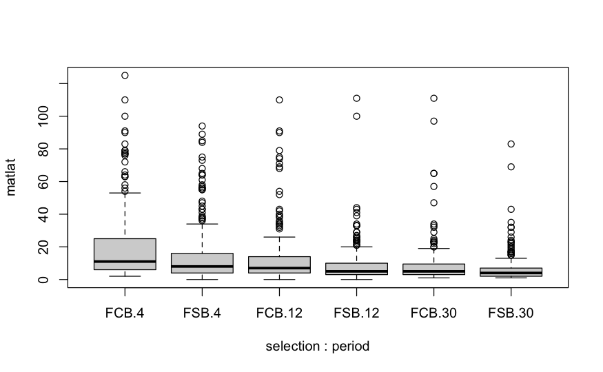

```r
boxplot(matlat~selection*period, data=singh)
```

Fit OLS anova model to check residuals

```r
singh.aov <- aov(matlat~selection*period*block, data=singh)
```

Check residuals - variance increases with mean

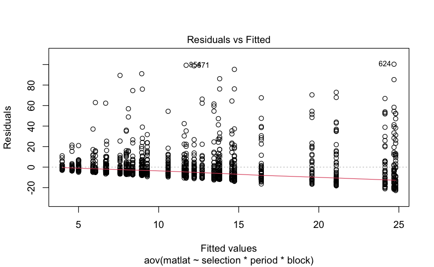

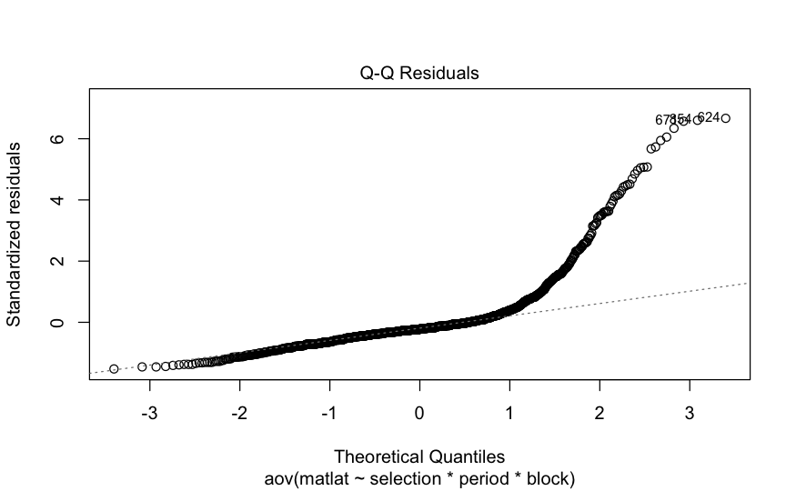

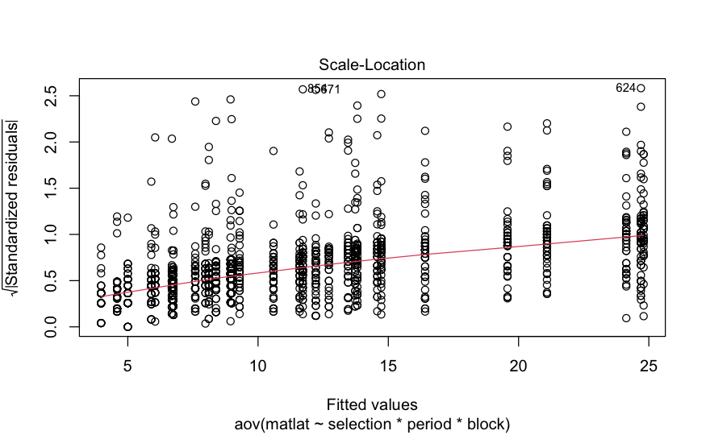

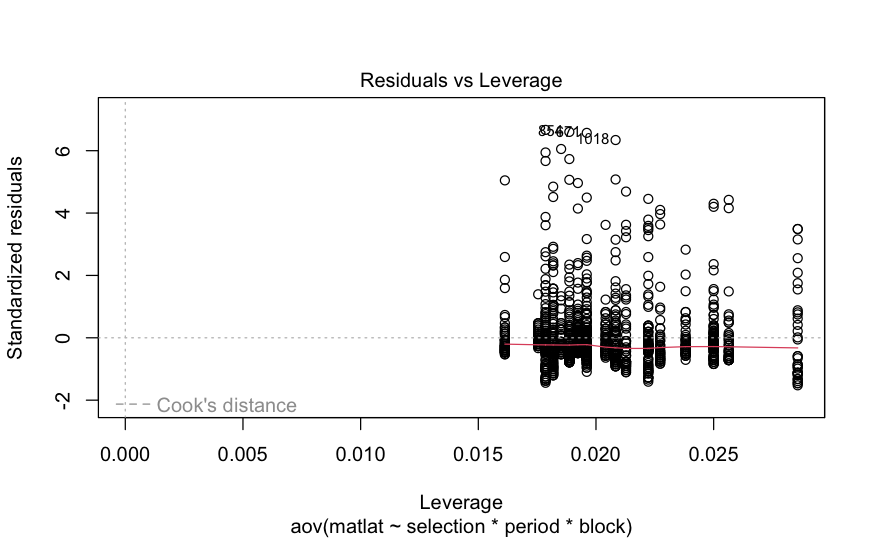

```r
plot(singh.aov)
```

Transform response to logs (+1 to handle zero values)

```r
singh$lmatlat <- log10(singh$matlat+1)
```

Check assumptions - much improved boxplots

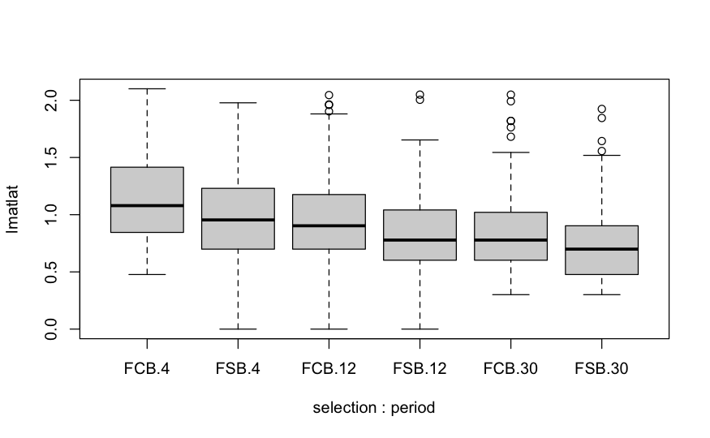

```r
boxplot(lmatlat~selection*period, data=singh)
```

Refit OLS model and check residuals (much better)

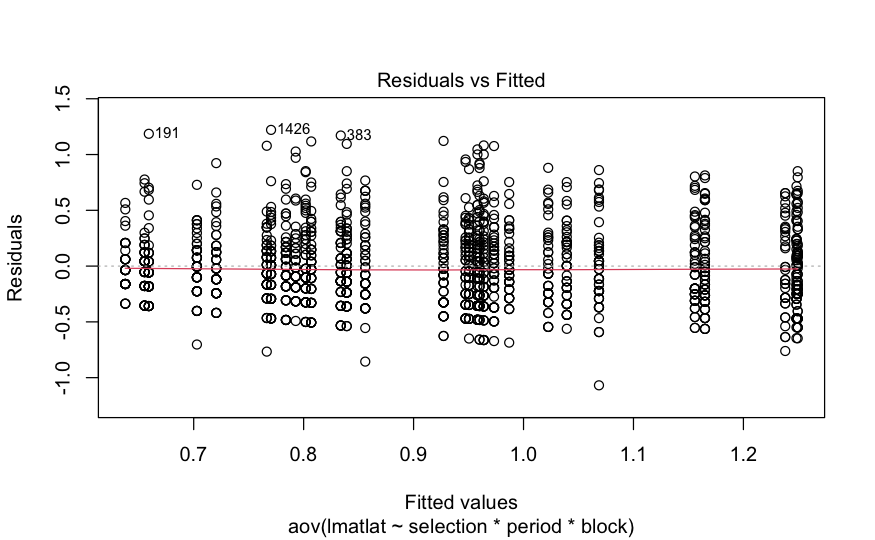

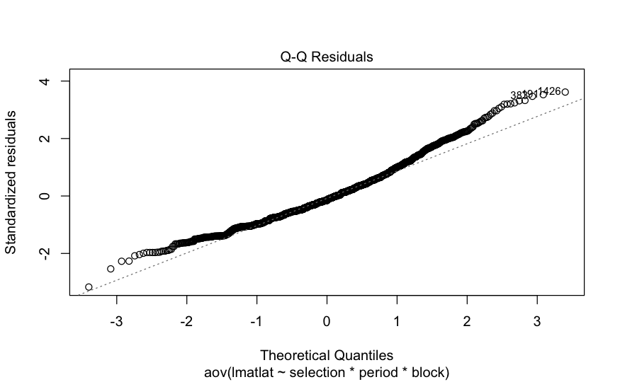

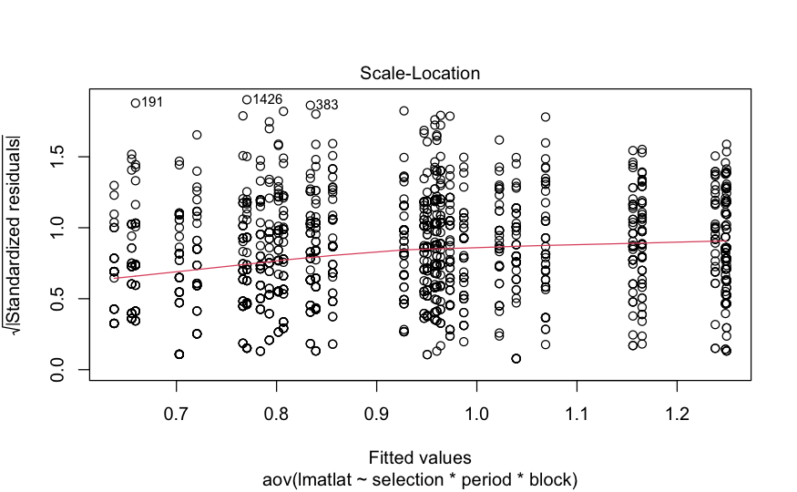

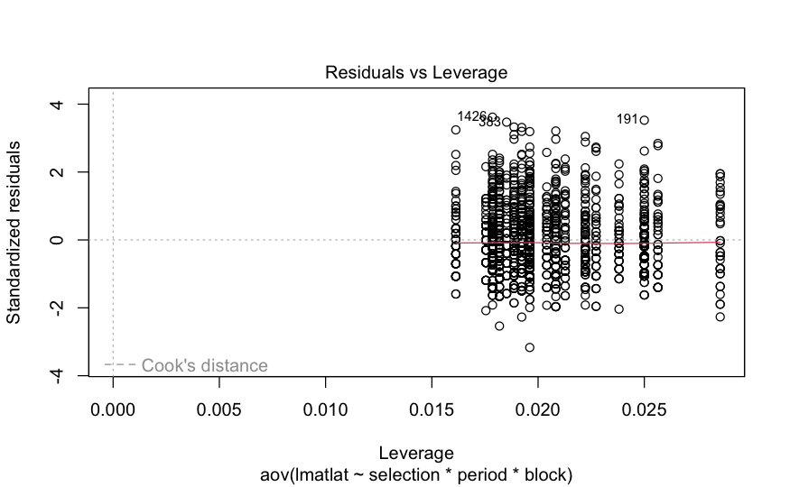

```r
singh.aov1 <- aov(lmatlat~selection*period*block, data=singh)
plot(singh.aov1)
```

### Use transformed data

Although the original paper used untransformed data, our pre-analysis checks suggest that a data transformation, or, as in later chapters, a generalized linear model, might be a better fit

### Fit lm models to get type III SS using car

```r
singh.lm1 <- lm(lmatlat ~ selection*period*block, data=singh)
summary(singh.lm1)
```

```
Call:
lm(formula = lmatlat ~ selection * period * block, data = singh)

Residuals:
    Min      1Q  Median      3Q     Max
-1.0686 -0.2434 -0.0532  0.1889  1.2209

Coefficients:
                           Estimate Std. Error t value Pr(>|t|)
(Intercept)                9.16e-01   8.94e-03  102.50  < 2e-16 ***
selection1                 5.83e-02   8.94e-03    6.53  9.3e-11 ***
period1                    1.63e-01   1.27e-02   12.83  < 2e-16 ***
period2                   -1.72e-02   1.26e-02   -1.37  0.17192
block1                    -7.79e-02   1.89e-02   -4.13  3.8e-05 ***
block2                     6.64e-02   1.82e-02    3.66  0.00026 ***
block3                     1.10e-01   1.74e-02    6.35  3.0e-10 ***
block4                     3.52e-02   1.79e-02    1.97  0.04908 *
selection1:period1         6.08e-03   1.27e-02    0.48  0.63170
selection1:period2         6.95e-03   1.26e-02    0.55  0.58136
selection1:block1         -2.72e-02   1.89e-02   -1.44  0.14888
selection1:block2          1.77e-02   1.82e-02    0.98  0.32942
selection1:block3          2.62e-02   1.74e-02    1.50  0.13278
selection1:block4         -7.89e-03   1.79e-02   -0.44  0.65873
period1:block1            -9.68e-03   2.67e-02   -0.36  0.71704
period2:block1             5.37e-02   2.64e-02    2.04  0.04179 *
period1:block2             5.63e-02   2.61e-02    2.15  0.03133 *
period2:block2            -5.49e-02   2.56e-02   -2.15  0.03204 *
period1:block3            -3.02e-02   2.45e-02   -1.23  0.21859
period2:block3             5.54e-02   2.49e-02    2.23  0.02612 *
period1:block4             2.98e-02   2.55e-02    1.17  0.24249
period2:block4            -2.40e-02   2.50e-02   -0.96  0.33585
selection1:period1:block1 -5.95e-03   2.67e-02   -0.22  0.82391
selection1:period2:block1  3.47e-02   2.64e-02    1.32  0.18829
selection1:period1:block2 -4.56e-02   2.61e-02   -1.75  0.08098 .
selection1:period2:block2 -6.38e-03   2.56e-02   -0.25  0.80311
selection1:period1:block3 -1.76e-04   2.45e-02   -0.01  0.99427
selection1:period2:block3 -7.58e-05   2.49e-02    0.00  0.99757
selection1:period1:block4  4.79e-02   2.55e-02    1.88  0.06015 .
selection1:period2:block4 -3.49e-03   2.50e-02   -0.14  0.88895
---
Signif. codes:  0 ‘***’ 0.001 ‘**’ 0.01 ‘*’ 0.05 ‘.’ 0.1 ‘ ’ 1

Residual standard error: 0.341 on 1449 degrees of freedom
Multiple R-squared:  0.208, Adjusted R-squared:  0.192
F-statistic: 13.1 on 29 and 1449 DF,  p-value: <2e-16
```

```r
Anova(singh.lm1, type='III')
```

```
Anova Table (Type III tests)

Response: lmatlat
                       Sum Sq   Df  F value  Pr(>F)
(Intercept)              1219    1 10507.20 < 2e-16 ***
selection                   5    1    42.59 9.3e-11 ***
period                     23    2    99.44 < 2e-16 ***
block                      13    4    27.69 < 2e-16 ***
selection:period            0    2     0.53  0.5864
selection:block             1    4     1.14  0.3338
period:block                3    8     2.74  0.0054 **
selection:period:block      1    8     1.23  0.2755
Residuals                 168 1449
---
Signif. codes:  0 ‘***’ 0.001 ‘**’ 0.01 ‘*’ 0.05 ‘.’ 0.1 ‘ ’ 1
```

Get correct F-ratio and P value for selection x period

```r
f = 0.03/0.14
f
```

```
[1] 0.214
```

```r
1-pf(f, 2, 8, lower.tail = TRUE, log.p = FALSE)
```

```
[1] 0.812
```

Get correct F-ratio and P value for selection

```r
f = 4.72/0.13
f
```

```
[1] 36.3
```

```r
1-pf(f, 1, 4, lower.tail = TRUE, log.p = FALSE)
```

```
[1] 0.00382
```

Get correct F-ratio and P value for period

```r
f = 11.09/0.33
f
```

```
[1] 33.6
```

```r
1-pf(f, 2, 8, lower.tail = TRUE, log.p = FALSE)
```

```
[1] 0.000128
```

#### Use VCA package to get anova var comps - unreliable sue to imbalance in sample sizes

```r
singh.vca <- anovaMM(lmatlat~selection + period + selection*period + (block) + (selection*block) + (period*block) + (selection*period*block), singh)
```

```
Convert variable selection from "character" to "factor"!
```

```r
VCAinference(singh.vca, alpha=0.05, VarVC=TRUE, excludeNeg=FALSE, constrainCI=FALSE)
```

```
Inference from Mixed Model Fit
------------------------------

> VCA Result:
-------------

    [Fixed Effects]

                  int          selectionFCB          selectionFSB               period4              period12              period30  selectionFCB:period4  selectionFSB:period4
               0.7235                0.0967                0.0000                0.2906                0.1100                0.0000                0.0332                0.0000
selectionFCB:period12 selectionFSB:period12 selectionFCB:period30 selectionFSB:period30
               0.0322                0.0000                0.0000                0.0000


    [Variance Components]

  Name                   DF       SS       MS     VC     %Total  SD     CV[%]   Var(VC)
1 total                  419.9978                 0.1282 100     0.358  39.263
2 block                  4        12.7393  3.1848 0.0097 7.5916  0.0986 10.8181 1e-04
3 selection:block        4        0.523    0.1307 0*     0*      0*     0*      0
4 period:block           8        2.6243   0.328  0.0019 1.4688  0.0434 4.7585  0
5 selection:period:block 8        1.1446   0.1431 6e-04  0.4328  0.0236 2.5829  0
6 error                  1449     168.1046 0.116  0.116  90.5068 0.3406 37.3529 0

Mean: 0.912 (N = 1479)

Experimental Design: unbalanced  |  Method: ANOVA | * VC set to 0 | adapted MS used for total DF


> VC:
-----
                       Estimate CI LCL CI UCL One-Sided LCL One-Sided UCL
total                  0.1282   0.1125 0.1475 0.1148        0.1441
block                  0.0097   0*     0.0248 0*            0.0224
selection:block        0        0*     0.0016 0*            0.0013
period:block           0.0019   0*     0.0055 0*            0.0049
selection:period:block 6e-04    0*     0.0034 0*            0.003
error                  0.116    0.108  0.1249 0.1093        0.1235

> SD:
-----
                       Estimate CI LCL CI UCL One-Sided LCL One-Sided UCL
total                  0.358    0.3354 0.384  0.3389        0.3797
block                  0.0986   0*     0.1575 0*            0.1496
selection:block        0        0*     0.0395 0*            0.0362
period:block           0.0434   0*     0.074  0*            0.0699
selection:period:block 0.0236   0*     0.0586 0*            0.0545
error                  0.3406   0.3286 0.3535 0.3305        0.3514

> CV[%]:
--------
                       Estimate CI LCL  CI UCL  One-Sided LCL One-Sided UCL
total                  39.263   36.778  42.111  37.164        41.6359
block                  10.8181  0*      17.2708 0*            16.4055
selection:block        0        0*      4.3363  0*            3.9724
period:block           4.7585   0*      8.1098  0*            7.6705
selection:period:block 2.5829   0*      6.4271  0*            5.9782
error                  37.3529  36.0412 38.7644 36.2481       38.533


95% Confidence Level  | * CI-limits constrained to be >= 0
SAS PROC MIXED method used for computing CIs
```

Get least squares means for selection and period

```r
emmeans (singh.lm1, "selection")
```

```
NOTE: Results may be misleading due to involvement in interactions
```

```
 selection emmean     SE   df lower.CL upper.CL
 FCB        0.974 0.0130 1449    0.949    1.000
 FSB        0.858 0.0123 1449    0.834    0.882

Results are averaged over the levels of: period, block
Confidence level used: 0.95
```

```r
emmeans(singh.lm1, "period")
```

```
NOTE: Results may be misleading due to involvement in interactions
```

```
 period emmean     SE   df lower.CL upper.CL
 4       1.079 0.0156 1449    1.048    1.109
 12      0.899 0.0154 1449    0.869    0.929
 30      0.770 0.0155 1449    0.740    0.801

Results are averaged over the levels of: selection, block
Confidence level used: 0.95
```

### Backtransform values

FCB & FSB:

```r
#means
10^.974
```

```
[1] 9.42
```

```r
10^.858
```

```
[1] 7.21
```

```r
#lower CIs
10^.949
```

```
[1] 8.89
```

```r
10^ .834
```

```
[1] 6.82
```

```r
#upper CIs
10^1
```

```
[1] 10
```

```r
10^.882
```

```
[1] 7.62
```

Periods

```r
10^1.079
```

```
[1] 12
```

```r
10^.899
```

```
[1] 7.93
```

```r
10^.77
```

```
[1] 5.89
```

## Fit mixed effects model using REML

```r
singh.lmer1 <- lmer(lmatlat~selection + period +selection:period + (1|block) + (1|selection:block)
            + (1|period:block) + (1|selection:period:block), REML=TRUE, singh)
```

```
boundary (singular) fit: see help('isSingular')
```

```r
summary(singh.lmer1, ddf="Kenward-Roger")
```

```
Linear mixed model fit by REML. t-tests use Kenward-Roger's method ['lmerModLmerTest']
Formula: lmatlat ~ selection + period + selection:period + (1 | block) +      (1 | selection:block) + (1 | period:block) + (1 | selection:period:block)
   Data: singh

REML criterion at convergence: 1072

Scaled residuals:
   Min     1Q Median     3Q    Max
-3.219 -0.706 -0.118  0.558  3.666

Random effects:
 Groups                 Name        Variance Std.Dev.
 selection:period:block (Intercept) 0.000473 0.0217
 period:block           (Intercept) 0.001876 0.0433
 selection:block        (Intercept) 0.000000 0.0000
 block                  (Intercept) 0.009328 0.0966
 Residual                           0.116030 0.3406
Number of obs: 1479, groups:  selection:period:block, 30; period:block, 15; selection:block, 10; block, 5

Fixed effects:
                   Estimate Std. Error       df t value Pr(>|t|)
(Intercept)         0.91634    0.04568  4.00065   20.06  3.6e-05 ***
selection1          0.05922    0.00977  3.95933    6.06   0.0039 **
period1             0.16275    0.02103  8.02693    7.74  5.4e-05 ***
period2            -0.01835    0.02098  7.97861   -0.87   0.4072
selection1:period1  0.00571    0.01384  7.97814    0.41   0.6909
selection1:period2  0.00519    0.01377  7.90483    0.38   0.7160
---
Signif. codes:  0 ‘***’ 0.001 ‘**’ 0.01 ‘*’ 0.05 ‘.’ 0.1 ‘ ’ 1

Correlation of Fixed Effects:
            (Intr) slctn1 perid1 perid2 slc1:1
selection1   0.010
period1      0.001  0.005
period2     -0.001  0.011 -0.500
slctn1:prd1  0.001  0.007  0.033 -0.026
slctn1:prd2  0.004 -0.004 -0.026  0.038 -0.501
optimizer (nloptwrap) convergence code: 0 (OK)
boundary (singular) fit: see help('isSingular')
```

```r
anova(singh.lmer1, ddf="Kenward-Roger")
```

```
Type III Analysis of Variance Table with Kenward-Roger's method
                 Sum Sq Mean Sq NumDF DenDF F value Pr(>F)
selection          4.26    4.26     1  3.96   36.73 0.0039 **
period             8.34    4.17     2  8.00   35.96 0.0001 ***
selection:period   0.07    0.04     2  7.92    0.31 0.7400
---
Signif. codes:  0 ‘***’ 0.001 ‘**’ 0.01 ‘*’ 0.05 ‘.’ 0.1 ‘ ’ 1
```

### CI on REML variance components (remembering to square CIs from lmer with are in SD units)

```r
singh.ci1 <- confint.merMod(singh.lmer1, oldNames=FALSE)
```

[output not shown]

```r
singh.vc1 <- (singh.ci1)^2
print(singh.vc1)
```

```
                                         2.5 %   97.5 %
sd_(Intercept)|selection:period:block 0.00e+00 0.002792
sd_(Intercept)|period:block           5.12e-05 0.006111
sd_(Intercept)|selection:block        0.00e+00 0.002572
sd_(Intercept)|block                  2.10e-03 0.038632
sigma                                 1.08e-01 0.124796
(Intercept)                           6.70e-01 1.029152
selection1                            1.50e-03 0.006291
period1                               1.50e-02 0.041501
period2                               3.49e-03 0.000438
selection1:period1                    3.65e-04 0.000920
selection1:period2                    3.89e-04 0.000869
```

### Refit model omitting three way interaction to deal with singular fit

```r
singh.lmer2 <- lmer(lmatlat~selection + period +selection:period + (1|block) + (1|selection:block)
                     + (1|period:block), REML=TRUE, singh)
```

Compare models

```r
anova(singh.lmer1, singh.lmer2)
```

```
refitting model(s) with ML (instead of REML)
```

```
Data: singh
Models:
singh.lmer2: lmatlat ~ selection + period + selection:period + (1 | block) + (1 | selection:block) + (1 | period:block)
singh.lmer1: lmatlat ~ selection + period + selection:period + (1 | block) + (1 | selection:block) + (1 | period:block) + (1 | selection:period:block)
            npar  AIC  BIC logLik deviance Chisq Df Pr(>Chisq)
singh.lmer2   10 1054 1107   -517     1034
singh.lmer1   11 1056 1115   -517     1034     0  1          1
```

```r
AICc(singh.lmer1, singh.lmer2)
```

|  | df | AICc |
| --- | --- | --- |
| singh.lmer1 | 11 | 1095 |
| singh.lmer2 | 10 | 1093 |

Omitting the interaction has little effect on fit

### Get results from this reduced model

```r
summary(singh.lmer2, ddf="Kenward-Roger")
```

```
Linear mixed model fit by REML. t-tests use Kenward-Roger's method ['lmerModLmerTest']
Formula: lmatlat ~ selection + period + selection:period + (1 | block) +      (1 | selection:block) + (1 | period:block)
   Data: singh

REML criterion at convergence: 1073

Scaled residuals:
   Min     1Q Median     3Q    Max
-3.222 -0.705 -0.121  0.553  3.670

Random effects:
 Groups          Name        Variance Std.Dev.
 period:block    (Intercept) 2.12e-03 0.04610
 selection:block (Intercept) 8.77e-05 0.00937
 block           (Intercept) 9.29e-03 0.09640
 Residual                    1.16e-01 0.34085
Number of obs: 1479, groups:  period:block, 15; selection:block, 10; block, 5

Fixed effects:
                    Estimate Std. Error        df t value Pr(>|t|)
(Intercept)         9.16e-01   4.57e-02  4.00e+00   20.05  3.6e-05 ***
selection1          5.93e-02   9.41e-03  3.95e+00    6.31   0.0034 **
period1             1.63e-01   2.11e-02  8.03e+00    7.74  5.4e-05 ***
period2            -1.85e-02   2.10e-02  7.98e+00   -0.88   0.4035
selection1:period1  5.78e-03   1.26e-02  1.46e+03    0.46   0.6469
selection1:period2  4.89e-03   1.26e-02  1.46e+03    0.39   0.6972
---
Signif. codes:  0 ‘***’ 0.001 ‘**’ 0.01 ‘*’ 0.05 ‘.’ 0.1 ‘ ’ 1

Correlation of Fixed Effects:
            (Intr) slctn1 perid1 perid2 slc1:1
selection1   0.010
period1      0.001  0.005
period2     -0.001  0.011 -0.500
slctn1:prd1  0.002  0.008  0.036 -0.028
slctn1:prd2  0.004 -0.004 -0.028  0.041 -0.502
```

F tests of fixed effects (Type III SS) for this new model - same conclusions as above

```r
anova(singh.lmer2, ddf="Kenward-Roger")
```

```
Type III Analysis of Variance Table with Kenward-Roger's method
                 Sum Sq Mean Sq NumDF DenDF F value Pr(>F)
selection          4.62    4.62     1     4   39.80 0.0034 **
period             8.34    4.17     2     8   35.89 0.0001 ***
selection:period   0.08    0.04     2  1462    0.36 0.6969
---
Signif. codes:  0 ‘***’ 0.001 ‘**’ 0.01 ‘*’ 0.05 ‘.’ 0.1 ‘ ’ 1
```

#### Calculate CIs on var component for this new model

```r
singh.ci2 <- confint.merMod(singh.lmer2, oldNames=FALSE)
```

[output not shown]

```r
singh.vc2 <- (singh.ci2)^2
print(singh.vc2)
```

```
                                  2.5 %   97.5 %
sd_(Intercept)|period:block    4.89e-05 0.006111
sd_(Intercept)|selection:block 0.00e+00 0.002659
sd_(Intercept)|block           2.07e-03 0.038632
sigma                          1.08e-01 0.124796
(Intercept)                    6.71e-01 1.027682
selection1                     1.76e-03 0.005897
period1                        1.57e-02 0.040132
period2                        3.14e-03 0.000356
selection1:period1             3.64e-04 0.000920
selection1:period2             3.89e-04 0.000869
```

## Analysis using untransformed response

This is the approach used by the paper’s author’s. We’ve given the initial OLS fit, which you can adjust for the random effects by recalculating F-ratios as shown in the earlier code. You can easily also run the REML mixed effects model.

```r
options(digits=4)
singh.lm2 <- lm(matlat~selection*period*block, data=singh)
summary(singh.lm2)
```

```
Call:
lm(formula = matlat ~ selection * period * block, data = singh)

Residuals:
   Min     1Q Median     3Q    Max
-22.80  -6.94  -3.38   1.22 100.30

Coefficients:
                          Estimate Std. Error t value Pr(>|t|)
(Intercept)                11.9362     0.3983   29.97  < 2e-16 ***
selection1                  2.0177     0.3983    5.07  4.6e-07 ***
period1                     5.6324     0.5656    9.96  < 2e-16 ***
period2                    -1.0621     0.5615   -1.89   0.0587 .
block1                     -2.1440     0.8405   -2.55   0.0108 *
block2                      1.8845     0.8090    2.33   0.0200 *
block3                      3.2913     0.7750    4.25  2.3e-05 ***
block4                      1.1268     0.7957    1.42   0.1569
selection1:period1          0.8168     0.5656    1.44   0.1489
selection1:period2          0.1700     0.5615    0.30   0.7621
selection1:block1          -1.3873     0.8405   -1.65   0.0990 .
selection1:block2          -0.1761     0.8090   -0.22   0.8277
selection1:block3           1.4173     0.7750    1.83   0.0676 .
selection1:block4           0.5771     0.7957    0.73   0.4684
period1:block1             -1.4099     1.1906   -1.18   0.2366
period2:block1              1.6193     1.1747    1.38   0.1683
period1:block2              3.4923     1.1639    3.00   0.0027 **
period2:block2             -2.4888     1.1397   -2.18   0.0291 *
period1:block3             -0.3059     1.0925   -0.28   0.7795
period2:block3              1.7296     1.1083    1.56   0.1188
period1:block4              0.2358     1.1360    0.21   0.8356
period2:block4              0.0091     1.1132    0.01   0.9935
selection1:period1:block1  -0.8870     1.1906   -0.75   0.4564
selection1:period2:block1   1.5682     1.1747    1.33   0.1821
selection1:period1:block2  -0.8039     1.1639   -0.69   0.4898
selection1:period2:block2  -0.6862     1.1397   -0.60   0.5472
selection1:period1:block3  -0.1096     1.0925   -0.10   0.9201
selection1:period2:block3   0.0743     1.1083    0.07   0.9465
selection1:period1:block4   1.7904     1.1360    1.58   0.1152
selection1:period2:block4  -0.0457     1.1132   -0.04   0.9673
---
Signif. codes:  0 ‘***’ 0.001 ‘**’ 0.01 ‘*’ 0.05 ‘.’ 0.1 ‘ ’ 1

Residual standard error: 15.2 on 1449 degrees of freedom
Multiple R-squared:  0.13,  Adjusted R-squared:  0.113
F-statistic: 7.48 on 29 and 1449 DF,  p-value: <2e-16
```

```r
Anova(singh.lm2, type='III')
```

```
Anova Table (Type III tests)

Response: matlat
                       Sum Sq   Df F value  Pr(>F)
(Intercept)            206972    1  898.08 < 2e-16 ***
selection                5914    1   25.66 4.6e-07 ***
period                  25814    2   56.01 < 2e-16 ***
block                   11609    4   12.59 4.5e-10 ***
selection:period          805    2    1.75   0.175
selection:block          1278    4    1.39   0.236
period:block             4086    8    2.22   0.024 *
selection:period:block   1411    8    0.77   0.634
Residuals              333938 1449
---
Signif. codes:  0 ‘***’ 0.001 ‘**’ 0.01 ‘*’ 0.05 ‘.’ 0.1 ‘ ’ 1
```

```r
#use anova to show MS
anova(singh.lm2)
```

```
Analysis of Variance Table

Response: matlat
                         Df Sum Sq Mean Sq F value  Pr(>F)
selection                 1   5766    5766   25.02 6.4e-07 ***
period                    2  25108   12554   54.47 < 2e-16 ***
block                     4  11607    2902   12.59 4.5e-10 ***
selection:period          2    637     319    1.38   0.251
selection:block           4   1255     314    1.36   0.245
period:block              8   4178     522    2.27   0.021 *
selection:period:block    8   1411     176    0.77   0.634
Residuals              1449 333938     230
---
Signif. codes:  0 ‘***’ 0.001 ‘**’ 0.01 ‘*’ 0.05 ‘.’ 0.1 ‘ ’ 1
```

```r
glance(singh.lm2)
```

| r.squared | adj.r.squared | sigma | statistic | p.value | df | logLik | AIC | BIC | deviance | df.residual | nobs |
| --- | --- | --- | --- | --- | --- | --- | --- | --- | --- | --- | --- |
| 0.13 | 0.113 | 15.2 | 7.48 | 3.44e-28 | 29 | -6106 | 12275 | 12439 | 333938 | 1449 | 1479 |